# Reproducing the marine seismic hazard-chain results

Network topology of marine seismic hazard chains and contrasts with inland earthquake chains — one document that regenerates every table and figure

Shi, Hu, Zhang

2026-11-12

[**GitHub repository**](https://github.com/hazardchain/marine-seismic-hazard-chains-code-data) · [**Interactive network viewer**](https://hazardchain.github.io/marine-seismic-hazard-chains-code-data/)

> Code blocks are folded for readability — click **Code** next to any output to see exactly how it is produced, or use the **Code ▾** menu (top right) to unfold everything. The **Download Rmd** entry in the same menu saves this document’s source.

# 1 Overview

This single document reproduces **every number and figure** reported in the paper from the raw cascade tables in `data/`. Knit it (RStudio → *Knit*, or `rmarkdown::render("marine_hazard_chains_reproduction.Rmd")`) to regenerate:

| Output | Section |
| --- | --- |
| Marine network (39 nodes / 152 edges) | go to section |
| **Table 3** — high-degree nodes, in/out degree and hubs | go to section |
| **Table 4** — four-layer net flow | go to section |
| **Table 5** — 15-class marine vs inland (with the Table 2 class mapping) | go to section |
| **Sect. 2.1, Data and encoding** — composition of the two records: event years, catalogue causes, the nine non-earthquake or erroneous catalogue events and what excluding them changes | go to section |
| **Table 6 / Sect. 3.5, Independent-event test** — directed-edge coverage of the three independent events, with chance baselines and the 14 novel couplings | go to section |
| **Table 7 / Sect. 3.5, Independent-event test** — conclusions before and after merging the independent events | go to section |
| **Table 8 / Sect. 3.6, Node removal** — node removal (cascade reach, Eq. 6, exhaustive search) | go to section |
| **Figure 1** — marine network, in/out degree | go to section |
| **Figure 2** — marine vs inland, 15 classes | go to section |
| **Figure 3 / Sect. 3.4, Robustness and sampling sufficiency** — robustness & sampling sufficiency | go to section |
| **Figure 4 / Sect. 3.5, Independent-event test** — three independent events overlaid on the marine network | go to section |
| **Sect. 4, Discussion** — two-step reach of the submarine earthquake, documentation depth of the marine events, equal-sample check of the marine–inland contrast | go to section |

**Paths are relative** (this file sits at the repository root) and use `file.path()`, which is correct on Windows, Linux and macOS alike — no per-OS branching is needed (R also accepts `/` on Windows). The operating system this run used is printed in the Session information at the end.

```r
## Required packages (install once): docxtractr, igraph, dplyr
for (p in c("docxtractr", "igraph", "dplyr"))
  if (!requireNamespace(p, quietly = TRUE))
    stop(sprintf("Please install.packages('%s')", p))
suppressMessages({library(igraph); library(dplyr)})
cat("Running on:", Sys.info()[["sysname"]], "| R", as.character(getRversion()), "\n")
```

```
## Running on: Linux | R 4.4.3
```

```r
## Relative paths from the repository root (cross-platform via file.path()).
data_dir   <- "data"
marine_f   <- file.path(data_dir, "marine", "tsunami_Dohmen_2025_EQ.docx")
inland_f   <- file.path(data_dir, "mainland_china",
                        paste0("earthquake_table_China_4_", c("E", "N", "SW", "NW"), ".docx"))
## landslide cause and entry status of the 58 marine events, copied from the catalogue of
## Dohmen et al. (2025; PANGAEA, doi:10.1594/PANGAEA.979839), see data/README.md
catalogue_f <- file.path(data_dir, "marine", "marine_events_catalogue_status.csv")
stopifnot(file.exists(marine_f), all(file.exists(inland_f)), file.exists(catalogue_f))

## Inland comparison network (paper Sect. 2.1, Data and encoding): an inland earthquake has its epicentre on
## land and a hazard chain that does not involve a tsunami. Ten events of the China tables
## (nine Taiwan events and the 1994 Taiwan Strait event) have offshore epicentres or
## near-coast cascades and are excluded, which leaves 84 events and 500 chains.
inland_excluded <- c("1910-0023-TWN", "1922-0014-TWN", "1951-0044-TWN", "1959-0050-TWN",
                     "1986-0133-TWN", "1994-0307-CHN", "2002-0172-TWN", "2006-0688-TWN",
                     "2018-0059-TWN", "2024-0189-TWN")
```

# 2 Helper functions

`read_doc()` reads the first table of a `.docx`; the only column used is the machine-readable **`Proposed Encoding`** field (chains such as `SEQ,TS;TS,CFL;CFL,PP;`). `build_graph()` turns those encodings into a directed graph: chains are split on `;`, pairs on `,`, whitespace is trimmed so `" TS"` and `"TS"` are not treated as different nodes, and the union of all chains is de-duplicated. **Self-loops are retained** here (one edge, `PP -> PP`, exists in the record and is part of the 152-edge fine network; it is removed only for the 15-class comparison, exactly as the paper states). `event_of()` assigns every row to its source event (the ID is carried forward over continuation rows), so that `build_graph(..., exclude = )` can drop whole events.

```r
read_doc <- function(path) {
  tb <- docxtractr::docx_extract_tbl(docxtractr::read_docx(path), tbl_number = 1)
  as.data.frame(tb, check.names = FALSE)
}

## robustly locate the "Proposed Encoding" column (dot or space in the name)
encoding_of <- function(df) df[[ grep("Encoding", names(df), ignore.case = TRUE)[1] ]]

## source event of every row: the ID is carried forward over continuation rows, which
## have an empty ID, a bare direction (east, south, west, north, centre) or start with "and "
event_of <- function(df) {
  id <- trimws(as.character(df[[1]])); cur <- NA_character_; ev <- character(length(id))
  for (k in seq_along(id)) {
    if (!is.na(id[k]) && nzchar(id[k]) &&
        !grepl("^[\u4e1c\u5357\u897f\u5317\u4e2d]$", id[k]) && !startsWith(id[k], "and ")) cur <- id[k]
    ev[k] <- cur }
  ev
}

## exclude: event IDs whose rows are dropped (an event matches if its ID starts with one of them)
build_graph <- function(paths, exclude = NULL) {
  x   <- do.call(rbind, lapply(paths, read_doc))
  enc <- encoding_of(x)
  if (length(exclude)) {
    ev  <- event_of(x)
    enc <- enc[!vapply(ev, function(e) !is.na(e) && any(startsWith(e, exclude)), logical(1))]
  }
  from <- character(0); to <- character(0)
  for (s in enc) for (seg in strsplit(s, ";")[[1]]) {
    pr <- trimws(strsplit(seg, ",")[[1]])
    if (length(pr) >= 2 && all(nzchar(pr[1:2]))) { from <- c(from, pr[1]); to <- c(to, pr[2]) }
  }
  final <- dplyr::distinct(data.frame(from = from, to = to))  # unique directed edges (self-loops kept)
  igraph::graph_from_data_frame(final, directed = TRUE)
}
```

# 3 Marine network

The fine marine network is built from tsunami_Dohmen_2025_EQ.docx (366 documented cascade chains, 39 peril codes).

```r
g_marine <- build_graph(marine_f)
cat(sprintf("Marine fine network: %d nodes, %d directed edges (incl. 1 self-loop PP->PP)\n",
            vcount(g_marine), ecount(g_marine)))
```

```
## Marine fine network: 39 nodes, 152 directed edges (incl. 1 self-loop PP->PP)
```

# 4 Table 3: node degrees

In/out degree of every node on the **fine** network (self-loop retained, so the PP self-loop contributes +1 to both PP’s in- and out-degree, giving PP = in 9 / out 1, as in the paper). `net = out − in`.

```r
deg_tab <- data.frame(
  Code = V(g_marine)$name,
  In   = degree(g_marine, mode = "in"),
  Out  = degree(g_marine, mode = "out"),
  Net  = degree(g_marine, mode = "out") - degree(g_marine, mode = "in"),
  row.names = NULL)
## the paper's Table 3 lists the high-degree nodes: in- or out-degree >= 7, i.e. the larger
## of the two lies in the upper quartile of the 39 nodes
## hub (paper, Table 3 footnote; the only sense in which the paper uses the term): a
## high-degree node whose in- and out-degree are both >= 5 (the upper quartile of each) and
## within a factor of two of each other; the two hubs with the highest total degree are the
## main hubs
hub_role <- function(g) {
  di <- degree(g, mode = "in"); do <- degree(g, mode = "out")
  hub <- pmax(di, do) >= 7 & di >= 5 & do >= 5 & do <= 2 * di & di <= 2 * do
  role <- setNames(ifelse(hub, "hub", ""), names(di))
  role[names(sort((di + do)[hub], decreasing = TRUE))[1:2]] <- "main hub"
  role
}
hubs_of <- function(g) { r <- hub_role(g)
  sprintf("%s (main: %s)", paste(sort(names(r)[r != ""]), collapse = ", "),
          paste(sort(names(r)[r == "main hub"]), collapse = ", ")) }
q75 <- function(m) quantile(degree(g_marine, mode = m), .75)
cat(sprintf("upper quartile: in-degree %g, out-degree %g, larger of the two %g\n", q75("in"), q75("out"),
            quantile(pmax(degree(g_marine, mode = "in"), degree(g_marine, mode = "out")), .75)))
```

```
## upper quartile: in-degree 5, out-degree 5, larger of the two 6.5
```

```r
core <- deg_tab[deg_tab$In >= 7 | deg_tab$Out >= 7, ]
core$Hub <- hub_role(g_marine)[core$Code]
knitr::kable(core[order(-core$Out, -core$In), ], row.names = FALSE,
             caption = "Table 3 — high-degree nodes (in- or out-degree >= 7) and hubs.")
```

Table 3 — high-degree nodes (in- or out-degree >= 7) and hubs.

| Code | In | Out | Net | Hub |
| --- | --- | --- | --- | --- |
| SEQ | 0 | 29 | 29 |  |
| CF | 14 | 13 | -1 | main hub |
| EQ | 0 | 13 | 13 |  |
| TS | 9 | 12 | 3 | main hub |
| CFL | 5 | 8 | 3 | hub |
| FI | 7 | 7 | 0 | hub |
| NF | 12 | 5 | -7 |  |
| PHF | 9 | 3 | -6 |  |
| BI | 11 | 1 | -10 |  |
| PP | 9 | 1 | -8 |  |

# 5 Table 4: four-layer net flow

Nodes are aggregated into the four cascade layers; **net flow = out − in** summed over each layer’s members. Expected: **+42 / +1 / −16 / −27** (sums to 0).

```r
layer_fine <- c(
  SEQ="Trigger", EQ="Trigger", AS="Trigger", VE="Trigger",
  SLS="Natural", CLS="Natural", LS="Natural", RO="Natural", LB="Natural", SA="Natural",
  LI="Natural", GU="Natural", SUB="Natural", MB="Natural", TS="Natural", CFL="Natural",
  FF="Natural", MED="Natural", WP="Natural", WD="Natural", DI="Natural", FA="Natural",
  PHF="Engineering", SDF="Engineering", SPF="Engineering", SCF="Engineering", NFA="Engineering",
  FI="Engineering", EX="Engineering", CF="Engineering", NF="Engineering",
  MTD="Consequence", BI="Consequence", EC="Consequence", PP="Consequence",
  HD="Consequence", IR="Consequence", SU="Consequence", CP="Consequence")
L4 <- c("Trigger", "Natural", "Engineering", "Consequence")

layer_flow <- function(g, lmap, levels) {
  lay <- factor(lmap[V(g)$name], levels = levels)
  o <- tapply(degree(g, mode = "out"), lay, sum); o[is.na(o)] <- 0
  i <- tapply(degree(g, mode = "in"),  lay, sum); i[is.na(i)] <- 0
  data.frame(Layer = levels, Nodes = as.integer(table(lay)[levels]),
             `Out-flow` = as.integer(o[levels]), `In-flow` = as.integer(i[levels]),
             `Net flow` = as.integer(o[levels] - i[levels]),
             `Net %`   = round((o[levels] - i[levels]) / ecount(g) * 100, 1),
             check.names = FALSE)
}
t3 <- layer_flow(g_marine, layer_fine, L4)
knitr::kable(rbind(t3, data.frame(Layer="Total", Nodes=sum(t3$Nodes),
             `Out-flow`=sum(t3$`Out-flow`), `In-flow`=sum(t3$`In-flow`),
             `Net flow`=sum(t3$`Net flow`), `Net %`=round(sum(t3$`Net %`),1), check.names=FALSE)),
             row.names = FALSE, caption = "Table 4 — four-layer net flow (fine network).")
```

Table 4 — four-layer net flow (fine network).

| Layer | Nodes | Out-flow | In-flow | Net flow | Net % |
| --- | --- | --- | --- | --- | --- |
| Trigger | 4 | 46 | 4 | 42 | 27.6 |
| Natural | 18 | 63 | 62 | 1 | 0.7 |
| Engineering | 9 | 35 | 51 | -16 | -10.5 |
| Consequence | 8 | 8 | 35 | -27 | -17.8 |
| Total | 39 | 152 | 152 | 0 | 0.0 |

# 6 Table 5: 15-class comparison

Both chains are reduced to the **same 15 classes** and **simplified (duplicate edges and self-loops removed)** before any metric is computed. The 39 → 15 mapping (the paper’s Table 2, Sect. 2.4) is:

```r
coarse_map <- c(
  SEQ="EQ or AS", AS="EQ or AS", EQ="EQ or AS", VE="EQ or AS",
  GU="Mass Slide", SLS="Mass Slide", CLS="Mass Slide", LI="Mass Slide", MB="Mass Slide",
  SUB="Mass Slide", LS="Mass Slide", RO="Mass Slide", LB="Mass Slide", SA="Mass Slide",
  PHF="Critical Infra. Fail.", SDF="Critical Infra. Fail.", CF="Critical Infra. Fail.",
  NFA="Critical Infra. Fail.", SPF="Critical Infra. Fail.",
  BI="Business Interr.", MTD="Business Interr.", WP="Water Dil.", WD="Water Dil.",
  NF="Critical NET Fail.", SCF="Critical NET Fail.", FA="Flora an Fauna", MED="Flora an Fauna",
  FI="Fire", EX="Fire", IR="Healthcare Deg.", HD="Healthcare Deg.",
  TS="Flood", CFL="Flood", FF="Flood",
  EC="Econ. Crisis", DI="Disease", PP="Phy.-Psych. Trauma", CP="Culture Perils", SU="Social Unrest")
stopifnot(length(setdiff(V(g_marine)$name, names(coarse_map))) == 0)  # every marine node is mapped
```

```r
## contract the fine marine graph to 15 classes; the inland tables are already 15-class
grp <- factor(coarse_map[V(g_marine)$name])
g_marine_c <- contract(g_marine, as.integer(grp), vertex.attr.comb = "first")
V(g_marine_c)$name <- levels(grp)
g_marine_c   <- simplify(g_marine_c, remove.multiple = TRUE, remove.loops = TRUE)  # -> 57 edges

g_inland   <- build_graph(inland_f, exclude = inland_excluded)
g_inland_c <- simplify(g_inland, remove.multiple = TRUE, remove.loops = TRUE)  # -> 14 classes, 44 edges

## size of the inland record before and after the exclusion
xin <- do.call(rbind, lapply(inland_f, read_doc)); ev_in <- event_of(xin)
has_chain <- !is.na(encoding_of(xin)) & nzchar(trimws(encoding_of(xin)))
is_excl   <- vapply(ev_in, function(e) !is.na(e) && any(startsWith(e, inland_excluded)), logical(1))
cat(sprintf("China tables: %d events, %d chains | inland network: %d events, %d chains, %d classes, %d edges (%d events excluded)\n",
            length(unique(ev_in[has_chain])), sum(has_chain),
            length(unique(ev_in[has_chain & !is_excl])), sum(has_chain & !is_excl),
            vcount(g_inland_c), ecount(g_inland_c), length(unique(ev_in[has_chain & is_excl]))))
```

```
## China tables: 94 events, 605 chains | inland network: 84 events, 500 chains, 14 classes, 44 edges (10 events excluded)
```

The full Table 5 — comparable topology metrics **and** the four-layer net flow, combined in one table (Marine vs Inland), exactly as in the paper. Disease does not occur in the inland record, so the inland network has 14 classes. **Out/in-degree centralisation uses the paper’s Eq. (4)**, `sum(d_max − d_i) / (N−1)^2` (identical to `igraph::centr_degree` once self-loops are removed).

```r
## out/in-degree centralisation, paper Eq. (4): sum(d_max - d_i) / (N-1)^2
Cfree <- function(g, mode) { d <- degree(g, mode = mode); N <- vcount(g)
  sum(max(d) - d) / ((N - 1)^2) }

## 15-class -> four-layer map, for the net-flow rows
layer15 <- c("EQ or AS"="Trigger",
  "Mass Slide"="Natural","Water Dil."="Natural","Flora an Fauna"="Natural","Flood"="Natural","Disease"="Natural",
  "Critical Infra. Fail."="Engineering","Critical NET Fail."="Engineering","Fire"="Engineering",
  "Business Interr."="Consequence","Healthcare Deg."="Consequence","Econ. Crisis"="Consequence",
  "Phy.-Psych. Trauma"="Consequence","Culture Perils"="Consequence","Social Unrest"="Consequence")

## every reported Table 5 value for one 15-class graph, as a labelled character column
table4_col <- function(g) {
  nf <- layer_flow(g, layer15, L4)$`Net %`          # Trigger / Natural / Engineering / Consequence
  c(`Nodes / edges`             = sprintf("%d / %d", vcount(g), ecount(g)),
    `Network density`           = sprintf("%.3f", edge_density(g, loops = FALSE)),
    `Out-degree centralisation` = sprintf("%.3f", Cfree(g, "out")),
    `In-degree centralisation`  = sprintf("%.3f", Cfree(g, "in")),
    `Max out-degree`            = sprintf("%d",   max(degree(g, mode = "out"))),
    `Pure sources / sinks`      = sprintf("%d / %d", sum(degree(g, mode="in")==0),
                                                     sum(degree(g, mode="out")==0)),
    `Mean path length`          = sprintf("%.2f", mean_distance(g, directed = TRUE)),
    `Net flow — Trigger`        = sprintf("%+.1f%%", nf[1]),
    `Net flow — Natural`        = sprintf("%+.1f%%", nf[2]),
    `Net flow — Engineering`    = sprintf("%+.1f%%", nf[3]),
    `Net flow — Consequence`    = sprintf("%+.1f%%", nf[4]))
}
marine_col   <- table4_col(g_marine_c)
inland_col <- table4_col(g_inland_c)
knitr::kable(data.frame(Metric = names(marine_col),
                        `Marine (15 classes)` = unname(marine_col),
                        `Inland`              = unname(inland_col),
                        check.names = FALSE),
             row.names = FALSE,
             caption = "Table 5 — 15-class comparison: topology metrics and four-layer net flow.")
```

Table 5 — 15-class comparison: topology metrics and four-layer net flow.

| Metric | Marine (15 classes) | Inland |
| --- | --- | --- |
| Nodes / edges | 15 / 57 | 14 / 44 |
| Network density | 0.271 | 0.242 |
| Out-degree centralisation | 0.551 | 0.817 |
| In-degree centralisation | 0.168 | 0.237 |
| Max out-degree | 11 | 13 |
| Pure sources / sinks | 1 / 3 | 1 / 4 |
| Mean path length | 1.90 | 1.81 |
| Net flow — Trigger | +19.3% | +29.5% |
| Net flow — Natural | +3.5% | +2.3% |
| Net flow — Engineering | +8.8% | +13.6% |
| Net flow — Consequence | -31.6% | -45.5% |

# 7 Sect. 2.1, Data and encoding: composition of the two records

**What it shows / why:** the numbers that Sect. 2.1 (Data and encoding) gives for the two records. For the marine record: the 58 source events, their time span and how they split over time, and how the catalogue of Dohmen et al. (2025) attributes the 57 events taken from it. Their landslide cause and entry status are copied from the catalogue (PANGAEA, doi:10.1594/PANGAEA.979839) into `data/marine/marine_events_catalogue_status.csv`. Nine events are attributed to a cause other than an earthquake or flagged as erroneous entries. The chunk lists them, counts their chains and checks that excluding them leaves the sources, hubs and layer ordering reported in Sect. 3.1–3.2 and the marine column of Table 5 unchanged. For the inland record: the span of the 84 inland events.

```r
## directed pairs of a set of encodings, parsed exactly as in build_graph()
rc_pairs <- function(enc) {
  out <- list()
  for (s in enc) for (seg in strsplit(s, ";")[[1]]) {
    pr <- trimws(strsplit(seg, ",")[[1]])
    if (length(pr) >= 2 && all(nzchar(pr[1:2]))) out[[length(out) + 1]] <- pr[1:2] }
  if (length(out)) do.call(rbind, out) else matrix(character(0), 0, 2)
}

## marine record: source event of every chain, and the year in the event ID
xm      <- read_doc(marine_f)
rc_ev   <- event_of(xm)
rc_enc  <- encoding_of(xm)
rc_has  <- !is.na(rc_enc) & nzchar(trimws(rc_enc))
rc_evs  <- unique(rc_ev[rc_has])
rc_year <- as.integer(sub(".*_(\\d{3,4})$", "\\1", rc_evs))
stopifnot(length(rc_evs) == 58, sum(rc_has) == 366, !anyNA(rc_year))
cat(sprintf("marine record: %d events, %d chains, AD %d-%d | before 1900: %d, 1900-1999: %d, since 2000: %d\n",
            length(rc_evs), sum(rc_has), min(rc_year), max(rc_year),
            sum(rc_year < 1900), sum(rc_year >= 1900 & rc_year <= 1999), sum(rc_year >= 2000)))
```

```
## marine record: 58 events, 366 chains, AD 551-2024 | before 1900: 12, 1900-1999: 33, since 2000: 13
```

```r
## catalogue attribution (cause: EQ earthquake, U unknown, V volcanic activity,
## A anthropogenic activity, PA paraglacial conditions, PR precipitation)
cat_tab <- read.csv(catalogue_f, stringsAsFactors = FALSE, na.strings = "")
stopifnot(setequal(cat_tab$event_id, rc_evs))
in_cat  <- !is.na(cat_tab$landslide_cause)
cause_n <- table(cat_tab$landslide_cause[in_cat])
cat(sprintf("in the catalogue: %d events (not listed: %s) | cause: %s | erroneous entries: %d\n",
            sum(in_cat), paste(cat_tab$event_id[!in_cat], collapse = ", "),
            paste(names(cause_n), cause_n, collapse = ", "),
            sum(grepl("erroneous", cat_tab$catalogue_status))))
```

```
## in the catalogue: 57 events (not listed: East_Japan_2011) | cause: A 1, EQ 50, PA 1, U 4, V 1 | erroneous entries: 2
```

```r
## the nine events: a cause other than an earthquake, or an erroneous entry
noneq_events <- cat_tab$event_id[in_cat & (cat_tab$landslide_cause != "EQ" |
                                            grepl("erroneous", cat_tab$catalogue_status))]
## build_graph(exclude =) matches IDs by prefix, so make sure it hits exactly these events
stopifnot(sum(vapply(rc_evs, function(e) any(startsWith(e, noneq_events)), logical(1))) == length(noneq_events))
nine_tab <- cat_tab[cat_tab$event_id %in% noneq_events, c("event_id", "landslide_cause", "catalogue_status")]
nine_tab$chains <- vapply(nine_tab$event_id, function(e) sum(rc_has & rc_ev == e), integer(1))
knitr::kable(nine_tab, row.names = FALSE, col.names = c("Event", "Cause", "Catalogue status", "Chains"),
             caption = sprintf("The %d catalogue events attributed to a cause other than an earthquake or flagged as erroneous (%d of the %d chains).",
                               nrow(nine_tab), sum(nine_tab$chains), sum(rc_has)))
```

The 9 catalogue events attributed to a cause other than an earthquake or flagged as erroneous (14 of the 366 chains).

| Event | Cause | Catalogue status | Chains |
| --- | --- | --- | --- |
| LTT_BlackSea_2007 | U | okay | 1 |
| LTT_Marseilles_2004 | U | okay | 1 |
| LTT_Flores_1982 | EQ | erroneous entry | 6 |
| LTT_Kitimat_1975 | A | okay | 1 |
| LTT_Kitimat_1974 | PA | okay | 1 |
| LTT_PapuaNewGuinea_1972 | U | okay | 1 |
| LTT_Maine_1926 | U | okay | 1 |
| LTT_Hawaii_1919 | V | okay | 1 |
| LTT_PrinceWilliamSound_1908 | EQ | erroneous entry | 1 |

```r
## what excluding them changes
g_rc <- build_graph(marine_f, exclude = noneq_events)
ekey <- function(g) with(igraph::as_data_frame(g), paste(from, to, sep = "->"))
cat(sprintf("couplings documented only by these events: %s | network without them: %d nodes, %d edges\n",
            paste(setdiff(ekey(g_marine), ekey(g_rc)), collapse = ", "), vcount(g_rc), ecount(g_rc)))
```

```
## couplings documented only by these events: VE->TS | network without them: 39 nodes, 151 edges
```

```r
rc_summary <- function(g) {
  din <- degree(g, mode = "in"); dout <- degree(g, mode = "out")
  nf  <- layer_flow(g, layer_fine, L4)$`Net flow`
  c(`Pure sources`                     = paste(sort(names(din)[din == 0]), collapse = ", "),
    `Top out-degree / top in-degree`   = sprintf("%s (%d) / %s (%d)", names(which.max(dout)), max(dout),
                                                 names(which.max(din)), max(din)),
    `Hubs`                             = hubs_of(g),
    `NF in / out`                      = sprintf("%d / %d", din[["NF"]], dout[["NF"]]),
    `Layer net flow T/N/E/C`           = paste(sprintf("%+d", nf), collapse = " / "),
    `Net flow decreases down the layers` = as.character(all(diff(nf) < 0)))
}
grp_rc <- factor(coarse_map[V(g_rc)$name])
g_rc_c <- contract(g_rc, as.integer(grp_rc), vertex.attr.comb = "first")
V(g_rc_c)$name <- levels(grp_rc)
g_rc_c <- simplify(g_rc_c, remove.multiple = TRUE, remove.loops = TRUE)
rc_cmp <- data.frame(Quantity           = c(names(rc_summary(g_marine)), paste("Table 5:", names(marine_col))),
                     `All 58 events`    = c(rc_summary(g_marine), marine_col),
                     `Without the nine` = c(rc_summary(g_rc), table4_col(g_rc_c)), check.names = FALSE)
rc_cmp$Unchanged <- rc_cmp[[2]] == rc_cmp[[3]]
knitr::kable(rc_cmp, row.names = FALSE,
             caption = "Sources, hubs and layer ordering of the fine network, and the marine column of Table 5, with and without the nine events.")
```

Sources, hubs and layer ordering of the fine network, and the marine column of Table 5, with and without the nine events.

| Quantity | All 58 events | Without the nine | Unchanged |
| --- | --- | --- | --- |
| Pure sources | EQ, SEQ | EQ, SEQ | TRUE |
| Top out-degree / top in-degree | SEQ (29) / CF (14) | SEQ (29) / CF (14) | TRUE |
| Hubs | CF, CFL, FI, TS (main: CF, TS) | CF, CFL, FI, TS (main: CF, TS) | TRUE |
| NF in / out | 12 / 5 | 12 / 5 | TRUE |
| Layer net flow T/N/E/C | +42 / +1 / -16 / -27 | +41 / +2 / -16 / -27 | FALSE |
| Net flow decreases down the layers | TRUE | TRUE | TRUE |
| Table 5: Nodes / edges | 15 / 57 | 15 / 57 | TRUE |
| Table 5: Network density | 0.271 | 0.271 | TRUE |
| Table 5: Out-degree centralisation | 0.551 | 0.551 | TRUE |
| Table 5: In-degree centralisation | 0.168 | 0.168 | TRUE |
| Table 5: Max out-degree | 11 | 11 | TRUE |
| Table 5: Pure sources / sinks | 1 / 3 | 1 / 3 | TRUE |
| Table 5: Mean path length | 1.90 | 1.90 | TRUE |
| Table 5: Net flow — Trigger | +19.3% | +19.3% | TRUE |
| Table 5: Net flow — Natural | +3.5% | +3.5% | TRUE |
| Table 5: Net flow — Engineering | +8.8% | +8.8% | TRUE |
| Table 5: Net flow — Consequence | -31.6% | -31.6% | TRUE |

```r
## inland record: the span of the 84 inland events (year = first four digits in the event ID)
rc_in_evs  <- unique(ev_in[has_chain & !is_excl])
rc_in_year <- as.integer(regmatches(rc_in_evs, regexpr("[0-9]{4}", rc_in_evs)))
stopifnot(length(rc_in_evs) == 84, length(rc_in_year) == 84)
cat(sprintf("inland record: %d events, %d-%d\n", length(rc_in_evs), min(rc_in_year), max(rc_in_year)))
```

```
## inland record: 84 events, 1904-2023
```

# 8 Table 8 / Sect. 3.6, Node removal

**What it shows / how it is made:** the cascade reach $R(G)$ is the number of ordered hazard pairs $(i, j)$, $i \neq j$, joined by a directed path (the PP self-loop is ignored). Removing a set $S$ deletes its nodes together with their edges. Pairs that start or end in $S$ would vanish under any removal, so the paper’s Eq. (6) compares the reduced graph with the full graph restricted to the same nodes, $\Delta R(S) = \bigl(R_{V\setminus S}(G) - R(G-S)\bigr) / R_{V\setminus S}(G)$, the share of the remaining connectivity that depends on paths through $S$. The best sets of one, two and three nodes are found by **exhaustive search** over the nine engineering nodes (main result) and, for reference, over all 27 process-layer nodes. This reproduces Table 8 and the 619 / 576 / 409 pair counts of the Node removal subsection.

```r
gr <- simplify(g_marine, remove.loops = TRUE, remove.multiple = TRUE)  # reachability ignores the self-loop
reach_mat <- function(g) { D <- distances(g, mode = "out"); is.finite(D) & D > 0 }
M0 <- reach_mat(gr); dimnames(M0) <- list(V(gr)$name, V(gr)$name)   # M0[i, j]: j reachable from i in G
R0 <- sum(M0)

## Eq. (6): base = R_{V\S}(G), after = R(G - S), dR in %
removal <- function(S) {
  keep  <- setdiff(V(gr)$name, S)
  base  <- sum(M0[keep, keep])
  after <- sum(reach_mat(delete_vertices(gr, S)))
  c(base = base, after = after, dR = 100 * (base - after) / base)
}
## exhaustive search: the `top` best sets of size k from a candidate pool
best_sets <- function(pool, k, top = 2) {
  cmb <- combn(pool, k, simplify = FALSE)
  r   <- vapply(cmb, function(S) removal(S)[["dR"]], numeric(1))
  o   <- order(-r)[seq_len(min(top, length(r)))]
  data.frame(Size = k, `Removed set` = vapply(cmb[o], paste, character(1), collapse = " + "),
             Reduction = sprintf("%.1f%%", r[o]), check.names = FALSE)
}
eng  <- names(layer_fine)[layer_fine == "Engineering"]                 # 9 nodes
proc <- names(layer_fine)[layer_fine %in% c("Natural", "Engineering")]  # 27 nodes
## list each pool by single-node leverage, so that sets are printed strongest node first
by_single <- function(pool) pool[order(-vapply(pool, function(v) removal(v)[["dR"]], numeric(1)))]
eng <- by_single(eng); proc <- by_single(proc)
cf <- removal("CF")
cat(sprintf("R(G) = %d ordered pairs | removing CF: %d -> %d pairs among the remaining nodes (%.1f%%)\n",
            R0, cf[["base"]], cf[["after"]], cf[["dR"]]))
```

```
## R(G) = 619 ordered pairs | removing CF: 576 -> 409 pairs among the remaining nodes (29.0%)
```

```r
single <- data.frame(Node = eng, r = vapply(eng, function(v) removal(v)[["dR"]], numeric(1)))
single <- single[order(-single$r), ]
knitr::kable(data.frame(Node = single$Node, Reduction = sprintf("%.1f%%", single$r)), row.names = FALSE,
             caption = "Table 8 (engineering candidates) — single nodes.")
```

Table 8 (engineering candidates) — single nodes.

| Node | Reduction |
| --- | --- |
| CF | 29.0% |
| FI | 8.3% |
| NF | 6.2% |
| PHF | 2.1% |
| SDF | 0.0% |
| SPF | 0.0% |
| SCF | 0.0% |
| NFA | 0.0% |
| EX | 0.0% |

```r
knitr::kable(rbind(best_sets(eng, 2), best_sets(eng, 3)), row.names = FALSE,
             caption = "Table 8 (engineering candidates) — best and next-best pairs and triples (exhaustive search over 9 nodes).")
```

Table 8 (engineering candidates) — best and next-best pairs and triples (exhaustive search over 9 nodes).

| Size | Removed set | Reduction |
| --- | --- | --- |
| 2 | CF + FI | 41.1% |
| 2 | CF + NF | 36.8% |
| 3 | CF + FI + NF | 45.8% |
| 3 | CF + FI + SDF | 42.3% |

```r
nat <- names(layer_fine)[layer_fine == "Natural"]
nat_r <- vapply(nat, function(v) removal(v)[["dR"]], numeric(1))
cat(sprintf("best natural-process node: %s (%.1f%%)\n", names(which.max(nat_r)), max(nat_r)))
```

```
## best natural-process node: TS (8.9%)
```

```r
knitr::kable(rbind(best_sets(proc, 1), best_sets(proc, 2), best_sets(proc, 3)), row.names = FALSE,
             caption = "Table 8 (process-layer candidates, reference) — best and next-best sets (exhaustive search over 27 nodes).")
```

Table 8 (process-layer candidates, reference) — best and next-best sets (exhaustive search over 27 nodes).

| Size | Removed set | Reduction |
| --- | --- | --- |
| 1 | CF | 29.0% |
| 1 | TS | 8.9% |
| 2 | CF + FI | 41.1% |
| 2 | CF + TS | 39.1% |
| 3 | CF + TS + NF | 56.8% |
| 3 | CF + TS + FI | 52.2% |

```r
cat(sprintf("CF + FI + TS (fire in place of critical network failure): %.1f%%\n", removal(c("CF", "FI", "TS"))[["dR"]]))
```

```
## CF + FI + TS (fire in place of critical network failure): 52.2%
```

# 9 Figure 1

**What it shows / how it is made:** the fine 39-node marine network, drawn twice with a shared force-directed layout (`igraph::layout_with_fr`, `set.seed(123)` for reproducibility). Node **colour and size encode degree** on a yellow→red scale; panel (a) uses in-degree, panel (b) out-degree (zero-out-degree nodes white). This is the code behind the paper’s `Fig1.png`.

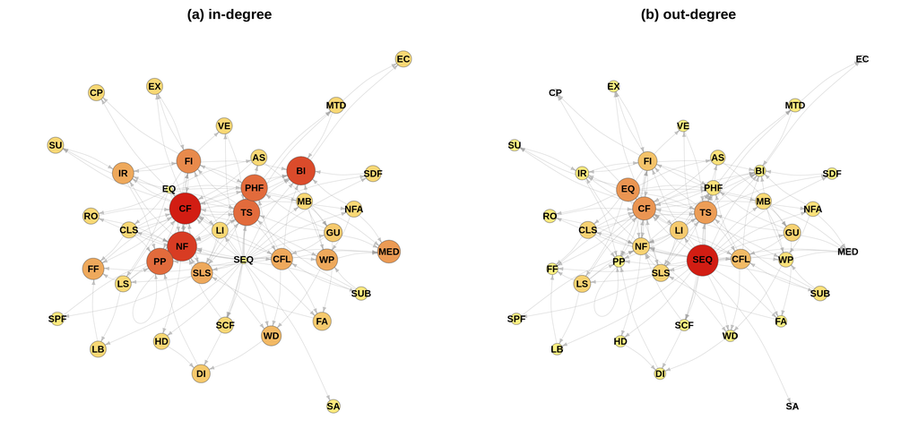

```r
pal <- colorRampPalette(c("#FFF886", "#d21d13"))
plot_deg <- function(g, layout, metric, zero_white = FALSE) {
  m <- metric / max(metric)
  col <- pal(500)[as.numeric(cut(m, breaks = 500))]; if (zero_white) col[metric == 0] <- "white"
  s <- sqrt(metric); vs <- 4 + (if (max(s)==0) 0 else s/max(s)) * 14
  plot(g, layout = layout, vertex.size = vs, vertex.color = col,
       vertex.frame.color = adjustcolor("grey30", .5),
       vertex.label = V(g)$name, vertex.label.family = "sans",
       vertex.label.color = "black", vertex.label.cex = .8, vertex.label.font = 2,
       edge.arrow.size = .35, edge.width = .6, edge.curved = .15,
       edge.color = adjustcolor("grey60", .45))
}
## helper: write a 300-dpi TIFF (LZW) and optionally a PNG of a plot, then draw it inline
export_fig <- function(plotfun, base, w, h) {
  dir.create("figures", showWarnings = FALSE)
  ## 300-dpi PNG
  png(file.path("figures", paste0(base, ".png")),
      width = w, height = h, units = "in", res = 300)
  plotfun(); invisible(dev.off())
  ## 300-dpi TIFF (LZW)
  tiff(file.path("figures", paste0(base, ".tif")),
       width = w, height = h, units = "in", res = 300, compression = "lzw")
  plotfun(); invisible(dev.off())
  plotfun()   # inline for the knitted HTML
}
set.seed(123); lay1 <- layout_with_fr(g_marine, niter = 3000)
draw_fig1 <- function() {
  par(mfrow = c(1, 2), mar = c(0, 0, 2, 0))
  plot_deg(g_marine, lay1, degree(g_marine, mode = "in"));  title("(a) in-degree")
  plot_deg(g_marine, lay1, degree(g_marine, mode = "out"), zero_white = TRUE); title("(b) out-degree")
}
export_fig(draw_fig1, "Fig1", 13, 6.2)
```

# 10 Figure 2

**What it shows / how it is made:** the marine (15 classes) and inland (14 classes) networks on **one shared force-directed layout** so each class sits in the same place across panels. Four panels: marine in/out degree, inland in/out degree; colour and size encode degree. The layout is computed, as in v1.0.1, on the marine network together with the complete China tables (all 94 events), so that every class keeps the position it has in the earlier version of the figure; the inland panels themselves draw only the 84 inland events. This is the code behind `Fig2.png`.

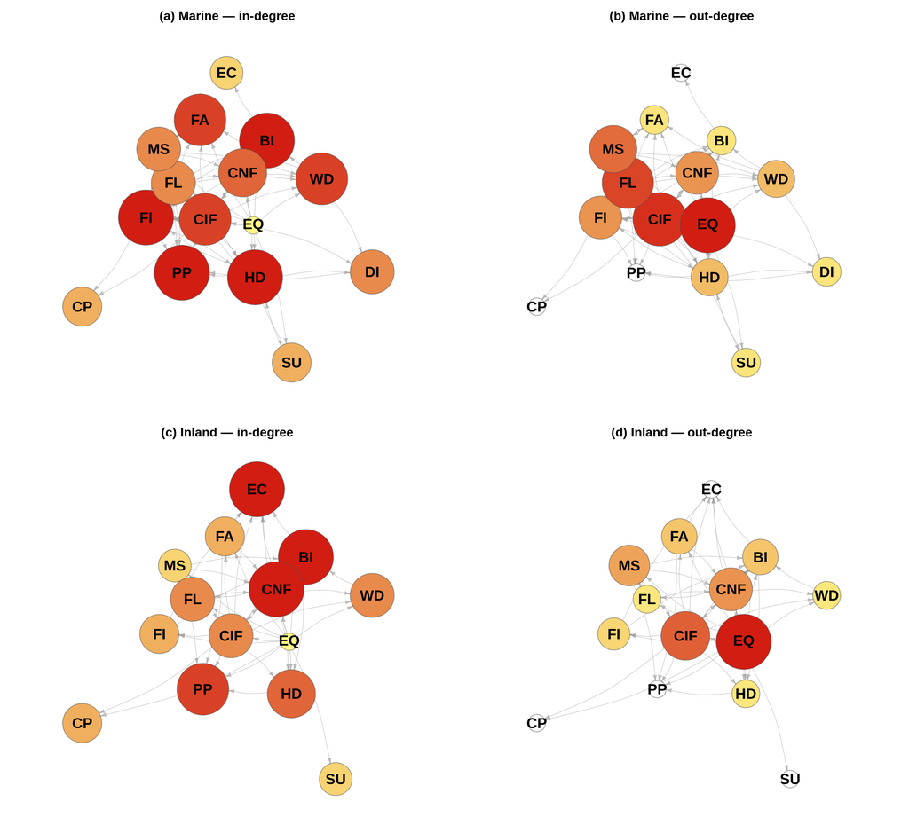

```r
abbr <- c("EQ or AS"="EQ","Mass Slide"="MS","Critical Infra. Fail."="CIF","Business Interr."="BI",
  "Water Dil."="WD","Critical NET Fail."="CNF","Flora an Fauna"="FA","Fire"="FI",
  "Healthcare Deg."="HD","Flood"="FL","Econ. Crisis"="EC","Disease"="DI",
  "Phy.-Psych. Trauma"="PP","Culture Perils"="CP","Social Unrest"="SU")
g_china_all_c <- simplify(build_graph(inland_f), remove.multiple = TRUE, remove.loops = TRUE)  # layout only
common <- sort(unique(c(V(g_marine_c)$name, V(g_china_all_c)$name)))
uni <- graph_from_data_frame(
  rbind(igraph::as_data_frame(g_marine_c), igraph::as_data_frame(g_china_all_c)),
  directed = TRUE, vertices = data.frame(name = common))
set.seed(123); lay2 <- layout_with_fr(uni, niter = 3000); rownames(lay2) <- V(uni)$name
panel <- function(g, mode, ttl) {
  m <- degree(g, mode = mode); mm <- if (max(m)==0) m else m/max(m)
  col <- pal(500)[as.numeric(cut(mm, breaks = 500))]; if (mode=="out") col[m==0] <- "white"
  s <- sqrt(m); vs <- 12 + (if (max(s)==0) 0 else s/max(s)) * 26
  plot(g, layout = lay2[V(g)$name, ], vertex.size = vs, vertex.color = col,
       vertex.frame.color = adjustcolor("grey30", .5), vertex.label = abbr[V(g)$name],vertex.label.family = "sans",
       vertex.label.color = "black", vertex.label.cex = 1.4, vertex.label.font = 2,
       edge.color = adjustcolor("grey60", .5), edge.width = .7, edge.arrow.size = .35,
       edge.curved = .15, main = ttl)
}
draw_fig2 <- function() {
  par(mfrow = c(2, 2), mar = c(1, 1, 2.5, 1))
  panel(g_marine_c, "in", "(a) Marine — in-degree");    panel(g_marine_c, "out", "(b) Marine — out-degree")
  panel(g_inland_c, "in", "(c) Inland — in-degree"); panel(g_inland_c, "out", "(d) Inland — out-degree")
}
export_fig(draw_fig2, "Fig2", 12, 11)
```

# 11 Figure 3 / Sect. 3.4, Robustness and sampling sufficiency

**What it shows / how it is made:** the 366 chains cluster under **58 source events (tsunamis)**, so all resampling is at the **event level** (cluster bootstrap). Panel (a) is the edge-accumulation (sampling-sufficiency) curve; panel (b) is the fraction of `B=1000` event-bootstrap resamples in which each qualitative conclusion holds (C1 pure sources; C2 highest out-degree SEQ, highest in-degree CF; C3 NF-as-convergence; C4 monotone four-layer cascade). The same `B` resamples also yield the 95% bootstrap intervals for the two degrees quoted in the Robustness subsection (submarine-earthquake out-degree and critical-infrastructure-failure in-degree); these are printed below the figure rather than plotted. The first check of the Robustness subsection — raising the edge-inclusion threshold to `>=1`, `>=2` and `>=3` independent events, which progressively removes low-frequency links — is also tabulated below the figure, showing which of C1–C4 survive at each threshold (only C3 fails, at the `>=3` core of 46 edges).

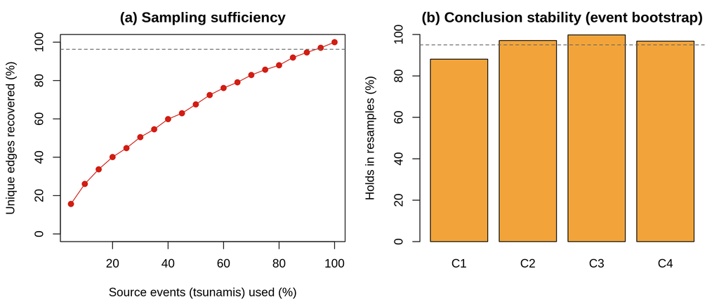

```r
set.seed(1)
x <- read_doc(marine_f)
id <- x[[ grep("^ID$|ID", names(x))[1] ]]; enc <- encoding_of(x)
cur <- NA; ev <- character(length(enc))                     # forward-fill event id
for (i in seq_along(enc)) { if (!is.na(id[i]) && nzchar(trimws(id[i]))) cur <- id[i]; ev[i] <- cur }
chain_edges <- lapply(seq_along(enc), function(i) {
  e <- character(0)
  for (seg in strsplit(enc[i], ";")[[1]]) { pr <- trimws(strsplit(seg, ",")[[1]])
    if (length(pr) >= 2 && all(nzchar(pr[1:2]))) e <- c(e, paste(pr[1], pr[2], sep = "|")) }
  unique(e) })
events   <- unique(ev)
ev_edges <- lapply(events, function(g) unique(unlist(chain_edges[ev == g])))
n_ev <- length(events); full <- length(unique(unlist(ev_edges)))
efreq <- table(unlist(ev_edges))

build_e  <- function(edges) { ee <- do.call(rbind, strsplit(edges, "\\|"))
  graph_from_data_frame(data.frame(from = ee[,1], to = ee[,2]), directed = TRUE) }
concl <- function(g) { dout <- degree(g, mode="out"); din <- degree(g, mode="in")
  nm <- V(g)$name; gv <- function(v,d) if (v%in%nm) d[v] else 0
  L <- layer_fine[nm]; nf <- sapply(L4, function(k) sum(dout[L==k]) - sum(din[L==k]))
  c(C1 = setequal(nm[din==0], c("SEQ","EQ")),
    C2 = (names(which.max(dout))=="SEQ" && names(which.max(din))=="CF"),
    C3 = (gv("NF",din) > gv("NF",dout)),
    C4 = (nf["Trigger"]>nf["Natural"] && nf["Natural"]>nf["Engineering"] &&
          nf["Engineering"]>nf["Consequence"] && nf["Trigger"]>0 && nf["Consequence"]<0)) }

## First check (Sect. 3.4, Robustness and sampling sufficiency): raise the inclusion threshold to >= 1, 2, 3
## independent events. Raising it strips low-frequency (single-event) links;
## C1-C4 are re-tested on each thresholded network to see which conclusions
## survive. (efreq counts, for every directed edge, the number of source
## events in which it appears.)
thr_check <- do.call(rbind, lapply(1:3, function(k) {
  keep <- names(efreq)[efreq >= k]
  cn   <- as.logical(concl(build_e(keep)))   # drop internal names; index by position
  data.frame(min_events = k, edges = length(keep),
             C1 = cn[1], C2 = cn[2], C3 = cn[3], C4 = cn[4]) }))

B <- 1000
stab <- rowMeans(sapply(1:B, function(b)
  concl(build_e(unique(unlist(ev_edges[sample(n_ev, n_ev, replace = TRUE)])))))) * 100

## 95% bootstrap intervals for the two degrees quoted in the Robustness subsection
## (event-level cluster bootstrap; reported in the text, not plotted in Fig. 3)
deg_boot <- sapply(1:B, function(b) {
  g  <- build_e(unique(unlist(ev_edges[sample(n_ev, n_ev, replace = TRUE)])))
  gd <- function(v, m) { d <- degree(g, mode = m); if (v %in% V(g)$name) d[[v]] else 0L }
  c(SEQ_out = gd("SEQ", "out"), CF_in = gd("CF", "in")) })
deg_ci <- function(x) sprintf("%.1f (95%% CI [%d, %d])", mean(x),
            as.integer(round(quantile(x, .025))), as.integer(round(quantile(x, .975))))

fr  <- seq(.05, 1, .05)
acc <- sapply(fr, function(f) { k <- max(1, round(f*n_ev))
  mean(sapply(1:200, function(s) length(unique(unlist(ev_edges[sample(n_ev, k)]))))) })
## Out-of-sample edge coverage (Sect. 3.4, Robustness and sampling sufficiency), for ALL held-out links and for the
## core links, averaged over many random 5-fold splits. A single split is noisy
## (and R's sample() RNG changed at R 3.6), so we average to get a stable,
## seed-robust value: all links ~74%, core ~96%. The core links are those
## documented in at least two events OF THE HELD-OUT FOLD, so that selecting them
## uses no information from the training events (v1.0.1 counted the events over
## the whole record, which leaks the training events into the selection, ~98%).
R_split  <- 200
fold_cov <- function(fold, core) mean(sapply(1:5, function(f) {
  tr <- unique(unlist(ev_edges[fold != f]))
  te <- unique(unlist(ev_edges[fold == f]))
  if (core) { tef <- table(unlist(ev_edges[fold == f])); te <- names(tef)[tef >= 2] }
  if (length(te) == 0) NA else 100 * sum(te %in% tr) / length(te) }), na.rm = TRUE)
cov_rep  <- sapply(1:R_split, function(r) {
  fold <- sample(rep(1:5, length.out = n_ev))
  c(all = fold_cov(fold, FALSE), core = fold_cov(fold, TRUE)) })
all_cov  <- mean(cov_rep["all",  ])
core_cov <- mean(cov_rep["core", ])

draw_fig3 <- function() {
  par(mfrow = c(1, 2), mar = c(4.2, 4.2, 2.4, 1))
  plot(100*fr, 100*acc/full, type = "o", pch = 19, col = "#d21d13", ylim = c(0,100),
       xlab = "Source events (tsunamis) used (%)", ylab = "Unique edges recovered (%)",
       main = "(a) Sampling sufficiency")
  abline(h = core_cov, lty = 2, col = "grey40")
  barplot(stab, col = "#F2A43A", ylim = c(0,100), names.arg = c("C1","C2","C3","C4"),
          ylab = "Holds in resamples (%)", main = "(b) Conclusion stability (event bootstrap)")
  abline(h = 95, lty = 2, col = "grey40")
}
export_fig(draw_fig3, "Fig3", 10, 4.2)
```

```r
cat(sprintf("events=%d | C1..C4 hold in %s%% | out-of-sample coverage: all links %.0f%%, >=2 core %.0f%%\n",
            n_ev, paste(round(stab), collapse="/"), all_cov, core_cov))
```

```
## events=58 | C1..C4 hold in 88/97/100/97% | out-of-sample coverage: all links 74%, >=2 core 96%
```

```r
cat(sprintf("degree bootstrap (Sect. 3.4): SEQ out-degree %s ; CF in-degree %s\n",
            deg_ci(deg_boot["SEQ_out", ]), deg_ci(deg_boot["CF_in", ])))
```

```
## degree bootstrap (Sect. 3.4): SEQ out-degree 24.0 (95% CI [17, 29]) ; CF in-degree 12.4 (95% CI [10, 14])
```

```r
cat("First check (Sect. 3.4) -- which conclusions survive as low-frequency links are removed:\n")
```

```
## First check (Sect. 3.4) -- which conclusions survive as low-frequency links are removed:
```

```r
print(thr_check, row.names = FALSE)
```

```
##  min_events edges   C1   C2    C3   C4
##           1   152 TRUE TRUE  TRUE TRUE
##           2    71 TRUE TRUE  TRUE TRUE
##           3    46 TRUE TRUE FALSE TRUE
```

# 12 Independent-event validation

**What it shows / why:** three major earthquake-generated tsunamis that are **not among the 58 compiled events** — the 2004 Indian Ocean (Sumatra-Andaman), the 1960 Valdivia (Chile) and the 2018 Palu (Sulawesi) events — are encoded as documented, individually sourced cascade chains in `data/marine/tsunami_extra_events_2004_1960_2018_EQ.docx` (a `Source` column, ignored by the analysis, carries the provenance). The 2004 and 1960 events are also absent from the landslide-tsunami catalogue; the 2018 Palu event is listed in it but was withheld from the compilation for this test. This section (1) draws the three events on their own, (2) overlays them on the paper’s network, and (3) tests whether the paper’s conclusions survive the new data, with chance baselines for the coverage.

## 12.1 The three events on their own

```r
extra_f <- file.path(data_dir, "marine", "tsunami_extra_events_2004_1960_2018_EQ.docx")
g_extra <- build_graph(extra_f)
cat(sprintf("Extra-events network: %d nodes, %d directed edges\n", vcount(g_extra), ecount(g_extra)))
```

```
## Extra-events network: 29 nodes, 54 directed edges
```

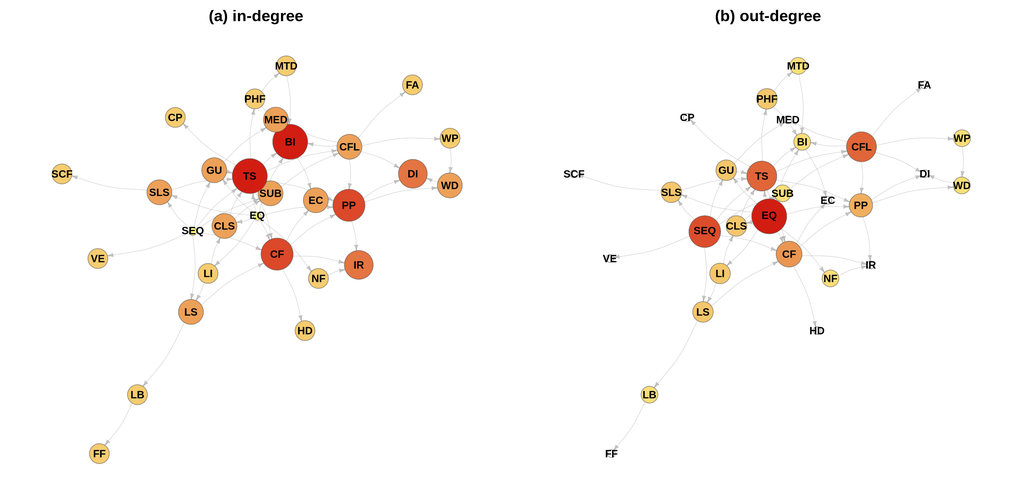

```r
set.seed(123); layE <- layout_with_fr(g_extra, niter = 3000)
par(mfrow = c(1, 2), mar = c(0, 0, 2, 0))
plot_deg(g_extra, layE, degree(g_extra, mode = "in"));  title("(a) in-degree")
plot_deg(g_extra, layE, degree(g_extra, mode = "out"), zero_white = TRUE); title("(b) out-degree")
```

## 12.2 Old versus new dataset size

```r
noloop <- function(g) ecount(simplify(g, remove.loops = TRUE, remove.multiple = FALSE))
meta <- function(path) {
  x <- read_doc(path); id <- x[[1]]; en <- encoding_of(x)
  cur <- NA; ev <- character(nrow(x)); nch <- 0L
  for (i in seq_len(nrow(x))) {
    if (!is.na(id[i]) && trimws(id[i]) != "") cur <- trimws(id[i])
    ev[i] <- cur
    if (!is.na(en[i]) && nzchar(trimws(en[i]))) nch <- nch + 1L
  }
  c(events = length(unique(ev)), chains = nch)
}
mo <- meta(marine_f); me <- meta(extra_f)
knitr::kable(data.frame(
  Dataset = c("Old (tsunami_Dohmen_2025_EQ)", "New (three extra events)"),
  Events  = c(mo[["events"]], me[["events"]]),
  Chains  = c(mo[["chains"]], me[["chains"]]),
  Nodes   = c(vcount(g_marine), vcount(g_extra)),
  `Edges (incl. self-loop)` = c(ecount(g_marine), ecount(g_extra)),
  `Edges (no self-loop)`    = c(noloop(g_marine), noloop(g_extra)),
  check.names = FALSE),
  row.names = FALSE, caption = "Node and edge counts of the old and new datasets.")
```

Node and edge counts of the old and new datasets.

| Dataset | Events | Chains | Nodes | Edges (incl. self-loop) | Edges (no self-loop) |
| --- | --- | --- | --- | --- | --- |
| Old (tsunami_Dohmen_2025_EQ) | 58 | 366 | 39 | 152 | 151 |
| New (three extra events) | 3 | 42 | 29 | 54 | 54 |

## 12.3 The three events overlaid on the paper’s network

New-event **nodes are coloured by layer** and their **labels are black**. Among the edges the three events contribute, the **14 links absent from the paper’s record are drawn in dark red**, the remaining new-event edges (already documented) in black, and every node, edge and label that comes only from the original network in grey. The dark-red edges are exactly the enrichment the new events add; the black-and-coloured footprint is what they reconfirm in the paper’s structure.

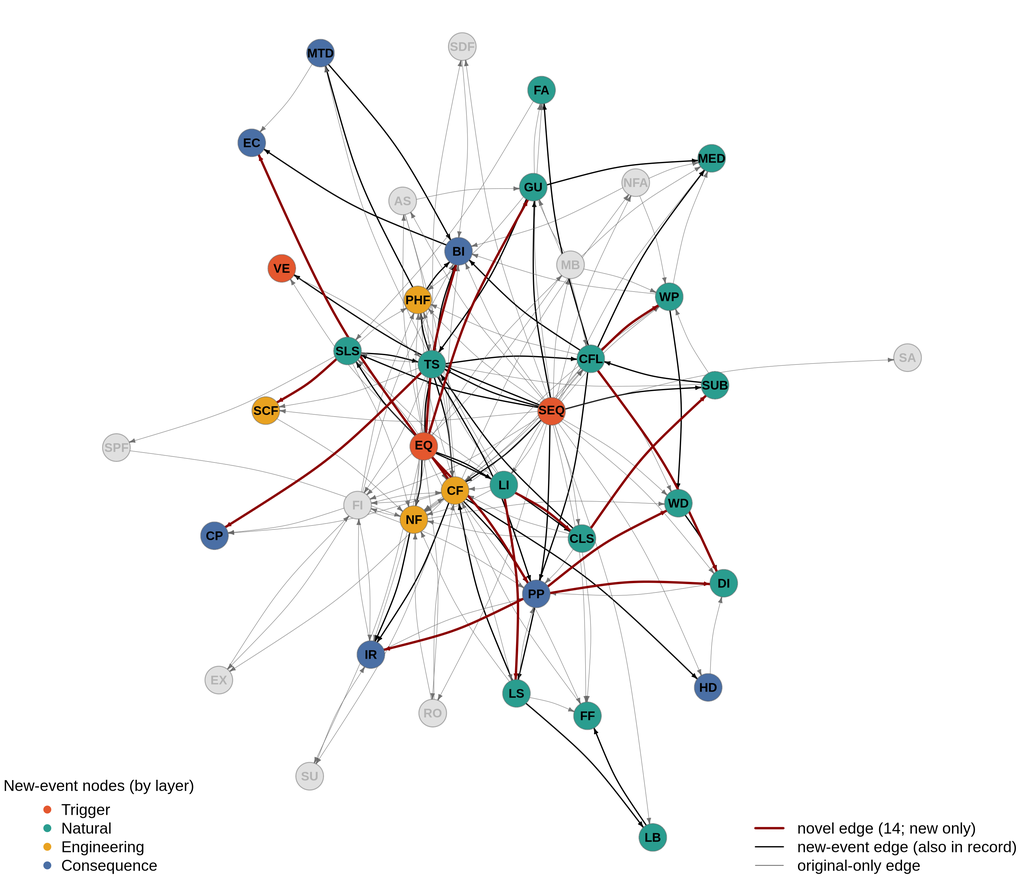

```r
lay_col <- c(Trigger = "#e4572e", Natural = "#2a9d8f",
             Engineering = "#e9a220", Consequence = "#4a6fa5")
E_orig  <- igraph::as_data_frame(g_marine)
E_extra <- igraph::as_data_frame(g_extra)
g_union <- graph_from_data_frame(unique(rbind(E_orig, E_extra)), directed = TRUE)

new_nodes <- V(g_extra)$name
new_ekey  <- paste(E_extra$from, E_extra$to)
ekey_union <- with(igraph::as_data_frame(g_union), paste(from, to))
old_ekey   <- paste(E_orig$from, E_orig$to)
is_new_e   <- ekey_union %in% new_ekey
is_novel_e <- is_new_e & !(ekey_union %in% old_ekey)   # the 14 links absent from the record
is_new_v   <- V(g_union)$name %in% new_nodes

vcol  <- ifelse(is_new_v, lay_col[layer_fine[V(g_union)$name]], "grey88")
vlcol <- ifelse(is_new_v, "black", "grey70")
ecol  <- ifelse(is_novel_e, "#8b0000", ifelse(is_new_e, "black", adjustcolor("grey40", .8)))
ewid  <- ifelse(is_novel_e, 2.4, ifelse(is_new_e, 1.3, .5))

set.seed(123); layU <- layout_with_fr(g_union, niter = 3000)
draw_overlay <- function() {
  par(mar = c(0, 0, 0, 0))
  plot(g_union, layout = layU,
       vertex.size = 7, vertex.color = vcol, vertex.frame.color = adjustcolor("grey40", .5),
       vertex.label = V(g_union)$name, vertex.label.family = "sans",
       vertex.label.color = vlcol, vertex.label.cex = .8, vertex.label.font = 2,
       edge.color = ecol, edge.width = ewid, edge.arrow.size = .3, edge.curved = .12)
  legend("bottomleft", legend = names(lay_col), col = lay_col, pch = 19, bty = "n",
         cex = 1.0, title = "New-event nodes (by layer)")
  legend("bottomright",
         legend = c("novel edge (14; new only)", "new-event edge (also in record)", "original-only edge"),
         col = c("#8b0000", "black", "grey40"), lwd = c(2.4, 1.3, .8), bty = "n", cex = 1.0)
}
## save standalone 300-dpi TIFF + PNG (publication quality), then render inline below
export_fig(draw_overlay, "Fig4", 11, 9.5)
```

## 12.4 Do the conclusions survive the new data?

```r
selfless <- function(df) df[df$from != df$to, , drop = FALSE]
orig_keys <- with(selfless(igraph::as_data_frame(g_marine)), paste(from, to))

## (A) directed-edge coverage, per event and combined
xx <- read_doc(extra_f); enc <- encoding_of(xx); id <- xx[[1]]
cur <- NA; ev <- character(nrow(xx))
for (i in seq_len(nrow(xx))) { if (!is.na(id[i]) && trimws(id[i]) != "") cur <- trimws(id[i]); ev[i] <- cur }
edges_of <- function(s) {
  e <- c(); for (p in strsplit(s, ";")[[1]]) { pr <- trimws(strsplit(p, ",")[[1]])
    if (length(pr) >= 2 && all(nzchar(pr[1:2])) && pr[1] != pr[2]) e <- c(e, paste(pr[1], pr[2])) }
  unique(e)
}
covA <- do.call(rbind, lapply(unique(ev), function(g) {
  ek <- unique(unlist(lapply(enc[ev == g], edges_of)))
  data.frame(Event = g, Links = length(ek), `In network` = sum(ek %in% orig_keys),
             Coverage = sprintf("%.0f%%", 100 * mean(ek %in% orig_keys)), check.names = FALSE) }))
old_ek <- unique(unlist(lapply(enc[ev %in% c("LTT_Chile_1960", "LTT_IndianOcean_2004")], edges_of)))
covA <- rbind(covA, data.frame(Event = "1960 + 2004 (outside the catalogue)", Links = length(old_ek),
              `In network` = sum(old_ek %in% orig_keys),
              Coverage = sprintf("%.0f%%", 100 * mean(old_ek %in% orig_keys)), check.names = FALSE))
all_ek <- unique(unlist(lapply(enc, edges_of)))
covA <- rbind(covA, data.frame(Event = "ALL THREE", Links = length(all_ek),
              `In network` = sum(all_ek %in% orig_keys),
              Coverage = sprintf("%.0f%%", 100 * mean(all_ek %in% orig_keys)), check.names = FALSE))
knitr::kable(covA, row.names = FALSE,
             caption = sprintf("(A) Directed-edge coverage of the three independent events by the paper's network (%d novel enrichment links).",
                               sum(!all_ek %in% orig_keys)))
```

(A) Directed-edge coverage of the three independent events by the paper’s network (14 novel enrichment links).

| Event | Links | In network | Coverage |
| --- | --- | --- | --- |
| LTT_IndianOcean_2004 | 26 | 19 | 73% |
| LTT_Chile_1960 | 17 | 16 | 94% |
| LTT_Palu_2018 | 29 | 22 | 76% |
| 1960 + 2004 (outside the catalogue) | 34 | 27 | 79% |
| ALL THREE | 54 | 40 | 74% |

```r
## the novel couplings, and how many of them involve a core node: the dominant source SEQ,
## the main hubs TS and CF, or the convergence node NF
novel_ek <- all_ek[!all_ek %in% orig_keys]
core_hit <- vapply(strsplit(novel_ek, " "), function(p) any(p %in% c("SEQ", "TS", "CF", "NF")), logical(1))
cat(sprintf("%d novel couplings: %s\n%d of them involve a core node (SEQ, TS, CF or NF): %s\n",
            length(novel_ek), paste(sub(" ", "->", novel_ek), collapse = ", "),
            sum(core_hit), paste(sub(" ", "->", novel_ek[core_hit]), collapse = ", ")))
```

```
## 14 novel couplings: SLS->SCF, CFL->WP, CF->EC, PP->DI, CFL->DI, TS->CP, PP->IR, LI->LS, LI->CLS, EQ->GU, CLS->SUB, EQ->PP, PP->WD, EQ->BI
## 2 of them involve a core node (SEQ, TS, CF or NF): CF->EC, TS->CP
```

```r
## (A2) chance baselines for the coverage (Sect. 3.5, Independent-event test): a random network with the same
## nodes and edges, and random rewirings that keep the in- and out-degree of every node
## (edge swaps a->b, c->d  =>  a->d, c->b; Maslov and Sneppen, 2002)
g_s <- simplify(g_marine, remove.loops = TRUE, remove.multiple = TRUE)
n_s <- vcount(g_s)
set.seed(1)
rew_cov <- replicate(1000, {
  g_r <- rewire(g_s, with = keeping_degseq(loops = FALSE, niter = 20 * ecount(g_s)))
  100 * mean(all_ek %in% with(igraph::as_data_frame(g_r), paste(from, to))) })
g_r <- rewire(g_s, with = keeping_degseq(loops = FALSE, niter = 20 * ecount(g_s)))
stopifnot(all(degree(g_r, mode = "in") == degree(g_s, mode = "in")),
          all(degree(g_r, mode = "out") == degree(g_s, mode = "out")))   # degrees are preserved
knitr::kable(data.frame(
  Network = c("Random, same nodes and edges (expected)", "Degree-preserving rewiring (1000 networks)",
              "Observed marine network"),
  Coverage = c(sprintf("%.1f%%", 100 * ecount(g_s) / (n_s * (n_s - 1))),
               sprintf("mean %.1f%%, 95th percentile %.1f%%, max %.1f%%", mean(rew_cov),
                       quantile(rew_cov, .95), max(rew_cov)),
               sprintf("%.1f%%", 100 * mean(all_ek %in% orig_keys)))),
  row.names = FALSE, caption = "(A2) Coverage of the 54 couplings of the three events: chance baselines.")
```

(A2) Coverage of the 54 couplings of the three events: chance baselines.

| Network | Coverage |
| --- | --- |
| Random, same nodes and edges (expected) | 10.2% |
| Degree-preserving rewiring (1000 networks) | mean 39.4%, 95th percentile 48.1%, max 53.7% |
| Observed marine network | 74.1% |

```r
## (B) conclusion stability on original vs augmented network
check <- function(g) {
  E_all <- ecount(simplify(g, remove.multiple = TRUE, remove.loops = FALSE))  # edge count incl. the PP self-loop
  g <- simplify(g, remove.multiple = TRUE, remove.loops = TRUE)
  nm <- V(g)$name; ind <- degree(g, mode = "in"); outd <- degree(g, mode = "out"); lv <- layer_fine[nm]
  net <- sapply(L4, function(k) sum(outd[lv == k]) - sum(ind[lv == k]))
  list(N = vcount(g), E = E_all, src = sort(nm[ind == 0]), hubs = hubs_of(g),
       to = nm[which.max(outd)], tov = max(outd), ti = nm[which.max(ind)], tiv = max(ind),
       nfi = ind[nm == "NF"], nfo = outd[nm == "NF"], net = net,
       C1 = setequal(nm[ind == 0], c("SEQ", "EQ")),
       C2 = (nm[which.max(outd)] == "SEQ" && nm[which.max(ind)] == "CF"),
       C3 = (ind[nm == "NF"] > outd[nm == "NF"]),
       C4 = (net[["Trigger"]] > net[["Natural"]] && net[["Natural"]] > net[["Engineering"]] &&
             net[["Engineering"]] > net[["Consequence"]] && net[["Trigger"]] > 0 && net[["Consequence"]] < 0))
}
g_aug <- graph_from_data_frame(unique(rbind(E_orig, E_extra)), directed = TRUE)
b0 <- check(g_marine); b1 <- check(g_aug)
fmt <- function(b) c(sprintf("%d / %d", b$N, b$E), paste(b$src, collapse = ", "),
  sprintf("%s (%d)", b$to, b$tov), sprintf("%s (%d)", b$ti, b$tiv), b$hubs, sprintf("%d / %d", b$nfi, b$nfo),
  sprintf("%+d / %+d / %+d / %+d", b$net[["Trigger"]], b$net[["Natural"]], b$net[["Engineering"]], b$net[["Consequence"]]),
  b$C1, b$C2, b$C3, b$C4)
tabB <- data.frame(Quantity = c("Nodes / edges", "Pure sources", "Top out-degree", "Top in-degree",
  "Hubs", "NF in / out", "Layer net flow T/N/E/C", "C1 sources are only SEQ,EQ",
  "C2 SEQ highest out-degree, CF highest in-degree", "C3 NF is convergence node", "C4 monotone four-layer cascade"),
  `Original (58 events)` = fmt(b0), `Augmented (61 events)` = fmt(b1), check.names = FALSE)
knitr::kable(tabB, row.names = FALSE,
             caption = "(B) The four conclusions and the hubs before and after merging the three independent events.")
```

(B) The four conclusions and the hubs before and after merging the three independent events.

| Quantity | Original (58 events) | Augmented (61 events) |
| --- | --- | --- |
| Nodes / edges | 39 / 152 | 39 / 166 |
| Pure sources | EQ, SEQ | EQ, SEQ |
| Top out-degree | SEQ (29) | SEQ (29) |
| Top in-degree | CF (14) | CF (14) |
| Hubs | CF, CFL, FI, TS (main: CF, TS) | CF, CFL, FI, TS (main: CF, TS) |
| NF in / out | 12 / 5 | 12 / 5 |
| Layer net flow T/N/E/C | +42 / +1 / -16 / -27 | +45 / +0 / -16 / -29 |
| C1 sources are only SEQ,EQ | TRUE | TRUE |
| C2 SEQ highest out-degree, CF highest in-degree | TRUE | TRUE |
| C3 NF is convergence node | TRUE | TRUE |
| C4 monotone four-layer cascade | TRUE | TRUE |

```r
## (C) node-importance rank stability (Spearman)
cm <- intersect(V(g_marine)$name, V(g_aug)$name)
so <- cor(degree(g_marine, mode = "out")[cm], degree(g_aug, mode = "out")[cm], method = "spearman")
si <- cor(degree(g_marine, mode = "in")[cm],  degree(g_aug, mode = "in")[cm],  method = "spearman")
knitr::kable(data.frame(Metric = c("Out-degree ranking", "In-degree ranking"),
  `Spearman (orig vs augmented)` = sprintf("%.3f", c(so, si)), check.names = FALSE),
  row.names = FALSE, caption = "(C) Node-importance rank stability under the new data.")
```

(C) Node-importance rank stability under the new data.

| Metric | Spearman (orig vs augmented) |
| --- | --- |
| Out-degree ranking | 0.974 |
| In-degree ranking | 0.955 |

# 13 Sect. 4, Discussion: supporting numbers

**What it shows / why:** three further numbers quoted in the Discussion. (1) How far the submarine earthquake reaches: the hazards it triggers directly and those it reaches within two steps. (2) Documentation depth: the marine events that document no consequence-layer hazard, and those whose chains stop at the natural-process layer. (3) An equal-sample check of the marine–inland contrast: 1000 random draws of 58 of the 84 inland events, each rebuilt as a 15-class network and compared with the marine network on density, out- and in-degree centralisation and consequence-layer net flow.

```r
## (1) reach of the submarine earthquake in the fine network
dc_d <- distances(g_marine, v = "SEQ", mode = "out")[1, ]
dc_d <- dc_d[names(dc_d) != "SEQ"]
cat(sprintf("SEQ triggers %d of the other %d hazards directly and reaches %d within two steps\n",
            sum(dc_d == 1), length(dc_d), sum(dc_d <= 2)))
```

```
## SEQ triggers 29 of the other 38 hazards directly and reaches 37 within two steps
```

```r
## (2) documentation depth: the layers that the chains of each marine event reach
dc_layers <- lapply(rc_evs, function(e) unique(layer_fine[c(rc_pairs(rc_enc[rc_has & rc_ev == e]))]))
stopifnot(!anyNA(unlist(dc_layers)))
dc_nocons <- !vapply(dc_layers, function(l) "Consequence" %in% l, logical(1))
dc_natend <- !vapply(dc_layers, function(l) any(c("Engineering", "Consequence") %in% l), logical(1))
cat(sprintf("marine events with no consequence-layer hazard: %d of %d; of these, stopping at the natural-process layer: %d\n",
            sum(dc_nocons), length(rc_evs), sum(dc_natend)))
```

```
## marine events with no consequence-layer hazard: 11 of 58; of these, stopping at the natural-process layer: 8
```

```r
## (3) equal-sample check: 1000 draws of 58 of the 84 inland events. Each event's
## couplings are parsed once; a draw is the union of its events' couplings, simplified
## (duplicate edges and self-loops removed) exactly as for Table 5.
dc_in_enc <- encoding_of(xin)
dc_in_key <- lapply(rc_in_evs, function(e) {
  p <- rc_pairs(dc_in_enc[has_chain & ev_in == e]); unique(paste(p[, 1], p[, 2], sep = "|")) })
dc_inland <- function(idx) {
  k <- do.call(rbind, strsplit(unique(unlist(dc_in_key[idx])), "|", fixed = TRUE))
  simplify(graph_from_data_frame(data.frame(from = k[, 1], to = k[, 2]), directed = TRUE),
           remove.multiple = TRUE, remove.loops = TRUE)
}
stopifnot(setequal(ekey(dc_inland(seq_along(rc_in_evs))), ekey(g_inland_c)))   # all 84 = the Table 5 network
dc_metrics <- function(g) c(edge_density(g, loops = FALSE), Cfree(g, "out"), Cfree(g, "in"),
                            layer_flow(g, layer15, L4)$`Net %`[4])
dc_marine <- dc_metrics(g_marine_c)
dc_inl84  <- dc_metrics(g_inland_c)
set.seed(1)
dc_draws  <- t(replicate(1000, dc_metrics(dc_inland(sample(length(rc_in_evs), 58)))))
dc_fmt    <- c("%.3f", "%.3f", "%.3f", "%+.1f%%")
dc_dir    <- c(-1, 1, 1, -1)   # inland: lower density, higher centralisation, more negative consequence flow
dc_share  <- vapply(1:4, function(j) 100 * mean(dc_dir[j] * (dc_draws[, j] - dc_marine[j]) > 0), numeric(1))
knitr::kable(data.frame(
  Metric = c("Network density (inland lower)", "Out-degree centralisation (inland higher)",
             "In-degree centralisation (inland higher)", "Net flow — Consequence (inland more negative)"),
  Marine                         = vapply(1:4, function(j) sprintf(dc_fmt[j], dc_marine[j]), ""),
  `Inland, 84 events`            = vapply(1:4, function(j) sprintf(dc_fmt[j], dc_inl84[j]), ""),
  `Inland, 58-event draws (range)` = vapply(1:4, function(j)
                                     paste(sprintf(dc_fmt[j], range(dc_draws[, j])), collapse = " to "), ""),
  `Draws in that direction`      = sprintf("%.0f%%", dc_share), check.names = FALSE),
  row.names = FALSE,
  caption = "Equal-sample check of the marine–inland contrast: 1000 random draws of 58 of the 84 inland events.")
```

Equal-sample check of the marine–inland contrast: 1000 random draws of 58 of the 84 inland events.

| Metric | Marine | Inland, 84 events | Inland, 58-event draws (range) | Draws in that direction |
| --- | --- | --- | --- | --- |
| Network density (inland lower) | 0.271 | 0.242 | 0.187 to 0.250 | 100% |
| Out-degree centralisation (inland higher) | 0.551 | 0.817 | 0.627 to 0.864 | 100% |
| In-degree centralisation (inland higher) | 0.168 | 0.237 | 0.178 to 0.333 | 100% |
| Net flow — Consequence (inland more negative) | -31.6% | -45.5% | -57.1% to -37.5% | 100% |

# 14 Interactive viewer data

**What it makes / why:** the interactive network viewer linked from the figure captions (`docs/index.html`, served at https://hazardchain.github.io/marine-seismic-hazard-chains-code-data/) is driven by `docs/graph-data.js`. This chunk regenerates that file **from the very same graph objects** used for the tables and figures above (`g_marine`, `g_marine_c`, `g_inland_c`), so the web page, the paper figures, and the tables are guaranteed to be one and the same network — no hand-maintained copy can drift. `jsonlite` ships with `rmarkdown`, so knitting this document already provides it. The only extra input is the human-readable peril names used for the tooltips.

```r
## full peril names for the 39 fine nodes (viewer tooltips only; no metric uses them)
full_name_fine <- c(
  SEQ="Submarine Earthquake", EQ="Coastal Earthquake", AS="Aftershock", VE="Volcanic Eruption",
  SLS="Submarine Landslide", CLS="Coastal Landslide", LS="Landslide", RO="Rockfall", LB="Lake Burst",
  SA="Snow Avalanche", LI="Liquefaction", GU="Ground Uplift", SUB="Subsidence", MB="Methane Blowout",
  TS="Tsunami", CFL="Coastal Flooding", FF="Fluvial Flood", MED="Marine Ecosystem Damage",
  WP="Water Pollution", WD="Water Dilemma", DI="Disease", FA="Flora and Fauna",
  PHF="Port / Harbour Failure", SDF="Seawall / Dike Failure", SPF="Subsea Pipeline Failure",
  SCF="Subsea Cable Failure", NFA="Nuclear Facility Accident", FI="Fire", EX="Explosion",
  CF="Critical Infrastructure Failure", NF="Critical Network Failure",
  MTD="Maritime Transport Disruption", BI="Business Interruption", EC="Economic Crisis",
  PP="Physical & Psychological Trauma", HD="Healthcare Degradation", IR="Insufficient Rescue",
  SU="Social Unrest", CP="Culture Perils")
stopifnot(setequal(names(full_name_fine), V(g_marine)$name))  # every fine node has a name

ident <- function(g) { n <- V(g)$name; setNames(n, n) }
mk_nodes <- function(g, label, full, layer) {
  nm <- V(g)$name
  df <- data.frame(id = nm, label = unname(label[nm]), full = unname(full[nm]),
                   layer = unname(layer[nm]),
                   `in`  = as.integer(degree(g, mode = "in")),
                   out   = as.integer(degree(g, mode = "out")),
                   check.names = FALSE, stringsAsFactors = FALSE)
  df[order(df$id), , drop = FALSE]                 # deterministic order (platform-independent)
}
mk_edges <- function(g) { e <- igraph::as_data_frame(g)[, c("from", "to")]
  e[order(e$from, e$to), , drop = FALSE] }

## overlay: union of the original network and the three independent events;
## per-node "isNew" flag (touched by a new event) and per-edge category
## (novel = in the new events only; new = in both; old = original only).
mk_nodes_overlay <- function(g) {
  nm <- V(g)$name
  data.frame(id = nm, label = nm, full = unname(full_name_fine[nm]),
             layer = unname(layer_fine[nm]),
             `in`  = as.integer(degree(g, mode = "in")),
             out   = as.integer(degree(g, mode = "out")),
             isNew = nm %in% new_nodes,
             check.names = FALSE, stringsAsFactors = FALSE)[order(nm), , drop = FALSE]
}
mk_edges_overlay <- function(g) {
  e <- igraph::as_data_frame(g)[, c("from", "to")]
  k <- paste(e$from, e$to); isN <- k %in% new_ekey; isO <- k %in% old_ekey
  e$cat <- ifelse(isN & !isO, "novel", ifelse(isN & isO, "new", "old"))
  e[order(e$from, e$to), , drop = FALSE]
}

GRAPHS <- list(
  fig1       = list(nodes = mk_nodes(g_marine,     ident(g_marine),     full_name_fine,     layer_fine),
                    edges = mk_edges(g_marine)),
  marine15   = list(nodes = mk_nodes(g_marine_c,   abbr, ident(g_marine_c),   layer15),
                    edges = mk_edges(g_marine_c)),
  inland15   = list(nodes = mk_nodes(g_inland_c,   abbr, ident(g_inland_c),   layer15),
                    edges = mk_edges(g_inland_c)),
  overlay    = list(nodes = mk_nodes_overlay(g_union), edges = mk_edges_overlay(g_union)))

if (!requireNamespace("jsonlite", quietly = TRUE)) {
  message("jsonlite not available; skipping docs/graph-data.js regeneration.")
} else if (dir.exists("docs")) {
  js <- paste0(
    "// Auto-generated by marine_hazard_chains_reproduction.Rmd from the docx sources in data/. Do not edit by hand.\n",
    "const GRAPHS = ", jsonlite::toJSON(GRAPHS, auto_unbox = TRUE, pretty = TRUE), ";\n")
  writeLines(js, file.path("docs", "graph-data.js"))
  cat(sprintf("Wrote docs/graph-data.js  |  fig1 %d/%d, marine15 %d/%d, inland15 %d/%d, overlay %d/%d (nodes/edges)\n",
    nrow(GRAPHS$fig1$nodes),       nrow(GRAPHS$fig1$edges),
    nrow(GRAPHS$marine15$nodes),   nrow(GRAPHS$marine15$edges),
    nrow(GRAPHS$inland15$nodes),   nrow(GRAPHS$inland15$edges),
    nrow(GRAPHS$overlay$nodes),    nrow(GRAPHS$overlay$edges)))
} else {
  message("docs/ folder not found next to marine_hazard_chains_reproduction.Rmd; skipping viewer regeneration.")
}
```

```
## Wrote docs/graph-data.js  |  fig1 39/152, marine15 15/57, inland15 14/44, overlay 39/166 (nodes/edges)
```

The web viewer therefore shares its single source of truth with Figs 1–2 and Tables 3–5: re-knit this document and the interactive page updates automatically.

# 15 Session information

**Platform and package versions of this run (click to expand)**

```r
cat("OS:", Sys.info()[["sysname"]], Sys.info()[["release"]], "\n")
```

```
## OS: Linux 6.17.4-76061704-generic
```

[session information not shown]